# Research designs

Choose a design by treatment timing, assumptions, and known effects.

The catalog links each design to the question it studies and to a public source when one exists. It also marks designs from ongoing work and designs made only to test the package.

```python
import matplotlib.pyplot as plt
import numpy as np

from pypanelsim import designs
```

## 1 At a glance

| Question | Family | Treatment timing | Known values |
| --- | --- | --- | --- |
| How does TWFE weight dynamic cohort effects? | Baker | staggered cohorts | cohort-event effects |
| Can a joint test detect effect heterogeneity? | F-test | one or several cohorts | temporal or cohort paths |
| How much should event-study cohorts be pooled? | Lepskii | many staggered cohorts | support-aware cohort paths |
| What happens when parallel trends hold only conditionally? | ATT-DML | one cohort or clustered timing | ATT and conditional trends |
| Can small regression summaries preserve a large experiment? | regression compression | one or two cohorts | event-time effects and sufficient summaries |
| How do mixed panel structures affect a counterfactual estimator? | composite panel | one cohort | missing treated outcomes |

## 2 Baker dynamic effects

Baker’s design shows why a two-way fixed-effects coefficient can differ from the average effect when cohorts adopt at different times and their effects grow at different rates. States enter one of three cohorts, untreated outcomes contain state and year effects, and each cohort has its own linear effect path. The simulation records cohort-event effects and the treated-cell ATT.

```python
baker_panel = designs.baker(
    config=designs.BakerPanelConfig(n_units=200),
    seed=42,
)
print(baker_panel.shape, round(baker_panel.true_att, 3))
```

```
(200, 36) 0.936
```

It translates Andrew Baker’s public JFE_DID simulation. See Baker TWFE failure.

## 3 F-test heterogeneity designs

The F-test designs ask whether a joint test can distinguish a common effect path from temporal or cohort heterogeneity. The temporal family has one adoption date and seven paths. The cohort family has three adoption cohorts and seven patterns of cohort differences. Untreated outcomes include fixed effects, trends, periodic components, and correlated errors.

```python
print(designs.available_ftest_temporal_designs())
print(designs.available_ftest_cohort_designs())

ftest_panel = designs.ftest_cohort(
    "selection_on_gains",
    config=designs.FTestCohortConfig(n_units=240),
    seed=42,
)
print(ftest_panel.truth.att_by_cohort()["att"])
```

```
('constant', 'linear', 'concave', 'positive_then_negative', 'exponential', 'sinusoidal', 'random_walk')
('homogeneous', 'log_vs_linear_vs_sin', 'small_differences', 'large_differences', 'selection_on_gains', 'novelty_effects', 'activity_bias')
[2.11678082 1.67395628 1.20835301]
```

The family follows the public TestingInEventStudies project and its paper, [When can we get away with using the two-way fixed effects regression?](https://arxiv.org/abs/2503.05125). See F-test heterogeneity designs.

## 4 Adaptive partial pooling

The adaptive-pooling designs ask which cohorts have similar enough event-time paths to pool and which comparisons lack calendar-time support. Nine adoption cohorts receive paths ranging from complete homogeneity to cohort-specific signed shapes. Untreated outcomes combine fixed effects, periodic time effects, and errors correlated across units and time.

```python
print(designs.available_lepskii_designs())

lepskii_panel = designs.lepskii(
    "tensor_blocks",
    config=designs.LepskiiPanelConfig(n_units=360),
    seed=42,
)
cells = lepskii_panel.truth.cohort_event(event_times=(-2, -1, 0, 1, 2))
print(cells.keys())
```

```
('complete_homogeneity', 'common_path', 'cohort_only_blocks', 'time_only_blocks', 'tensor_blocks', 'early_late_split', 'three_epoch', 'smooth_dose_gradient', 'response_timing', 'local_window_shock', 'log_shark_sin', 'no_pool_unique_signatures', 'no_pool_unique_peaks', 'no_pool_signed_paths')
dict_keys(['cohort', 'event_time', 'calendar_time', 'cohort_size', 'supported', 'effect'])
```

The family adapts an unpublished working-paper design. See Support-aware event studies.

## 5 Conditional and latent trends

The ATT-DML designs ask whether an estimator recovers the ATT when unconditional parallel trends fail but a conditional or latent version holds. Five variants cover linear and nonlinear conditional trends, stable and unstable latent trends, and clustered ARMA outcomes.

```python
print(designs.available_att_dml_designs())

conditional_panel = designs.att_dml(
    "conditional_parallel_trends_nonlinear",
    config=designs.ATTDMConditionalConfig(n_units=500),
    seed=42,
)
print(conditional_panel.unit_covariate_names[:5])
```

```
('conditional_parallel_trends', 'conditional_parallel_trends_nonlinear', 'latent_parallel', 'latent_nonparallel', 'clustered_arma')
('x1', 'x2', 'x3', 'x4', 'x5')
```

The designs isolate assumptions used in augmented balancing and double-machine-learning work. The related public source is [Augmented Balancing Estimators of the ATT](https://apoorvalal.github.io/files/papers/augbal.pdf). See Conditional and latent trends.

## 6 Large-panel regression summaries

The large-panel designs ask whether small regression summaries preserve the treatment-effect information in a large experiment. The main version combines fixed effects, unit trends, serially correlated errors, and a configurable effect path. The Anscombe variants keep selected summaries similar while changing unit, time, or cohort-time structure.

```python
compression_panel = designs.regression_compression(
    config=designs.RegressionCompressionConfig(n_units=400),
    seed=42,
)
print(compression_panel.shape)
print(designs.available_anscombe_designs())
```

```
(400, 35)
('zero', 'unit', 'time', 'cohort_time')
```

The family follows [Large Scale Longitudinal Experiments](https://arxiv.org/abs/2410.09952) and its [public code](https://github.com/py-econometrics/panel-at-scale-code). See Large panels and compressed regressions.

## 7 Composite panel benchmark

The composite design tests an estimator when untreated outcomes mix fixed effects, factors, time-series persistence, and sparse donor structure.

```python
composite_panel = designs.gsynth_composite(
    config=designs.GSynthCompositeConfig(n_control=80, n_treated=20),
    seed=42,
)
print(composite_panel.metadata["outcome"]["model"])
```

```
SumOutcomeModel
```

The maintainers assembled it as a package stress test; it does not reproduce a paper or another repository. See Composite panel benchmark.

## 8 One draw from each family

The gallery is descriptive, not an estimator comparison. Units are sorted by adoption time so treatment timing and untreated structure can be read together.

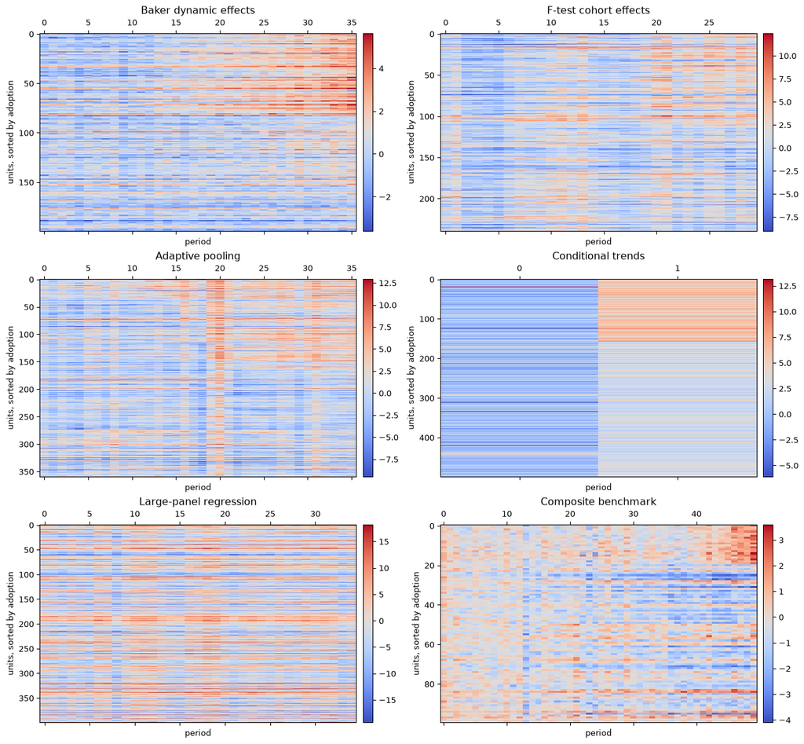

```python
gallery = {
    "Baker dynamic effects": baker_panel,
    "F-test cohort effects": ftest_panel,
    "Adaptive pooling": lepskii_panel,
    "Conditional trends": conditional_panel,
    "Large-panel regression": compression_panel,
    "Composite benchmark": composite_panel,
}

figure, axes = plt.subplots(3, 2, figsize=(13, 12), constrained_layout=True)
for axis, (label, draw) in zip(axes.ravel(), gallery.items(), strict=True):
    order = np.argsort(draw.adoption_times, kind="stable")
    image = axis.matshow(draw.outcome[order], aspect="auto", cmap="coolwarm")
    axis.set_title(label)
    axis.set_xlabel("period")
    axis.set_ylabel("units, sorted by adoption")
    figure.colorbar(image, ax=axis, fraction=0.035, pad=0.02)
plt.show()
```